# Introdução à Análise Exploratória de Dados

Kauê Dario RA: 161023177

14/03/2022

## Introdução

Este projeto final consiste em realizar uma Análise Exploratória de [Dados](https://moodle.unesp.br/mod/folder/view.php?id=76521) (AED) cujos [dados](https://moodle.unesp.br/mod/folder/view.php?id=76521) estão contidos em duas planilhas armazenadas no formato Excel (.xlsx).

De forma geral, a análise exploratória visará compreender como a pandemia do “novo coronavírus” está “impactando”** a vida das pessoas de uma determinada cidade.

Neste projeto, a AED deverá oferecer subsídios para identificar a característica dos casos e óbitos notificados de Covid-19 na cidade de Bauru:  
- distribuição de acordo com a idade dos pacientes:  
- verificar quais as características das comorbidades dos óbitos;  
- variação periódica de tais óbitos;  
- tipos e tempo de permanência hospitalar;  
- relação entre óbitos ocorridos e a vacinação dos falecidos.

Os [dados](https://moodle.unesp.br/mod/folder/view.php?id=76521) aqui apresentados foram obtidos através de reportagens publicadas nos anos de 2020 e 2022 no periódico “Jornal da Cidade”, editado na cidade de Bauru, interior do Estado de São Paulo (https://www.jcnet.com.br/) e representam uma síntese dos [dados](https://moodle.unesp.br/mod/folder/view.php?id=76521) divulgados pela Prefeitura Municipal de Bauru (https://www2.bauru.sp.gov.br/coronavirus/) nos seus informes epidemiológicos

## Análise dos Dados

### **Distribuição de óbitos entre idades**

[output not shown]

[output cut: 49 more lines]

```
## [1]   0 103
```

```
## [1] 103
```

```
## [1] 1142
```

```
## [1] 34
```

```
## [1] 4
```

```
##
##     [0,4)     [4,8)    [8,12)   [12,16)   [16,20)   [20,24)   [24,28)   [28,32)
##         2         0         0         0         2         3        10         7
##   [32,36)   [36,40)   [40,44)   [44,48)   [48,52)   [52,56)   [56,60)   [60,64)
##        18        28        34        47        60        82        93        91
##   [64,68)   [68,72)   [72,76)   [76,80)   [80,84)   [84,88)   [88,92)   [92,96)
##       113        88       101        95        84        76        63        30
##  [96,100) [100,104) [104,108) [108,112) [112,116) [116,120) [120,124) [124,128)
##        11         3         0         0         0         0         0         0
## [128,132) [132,136)
##         0         0
```

[figure not shown]

### **Características das comorbidades**

Neste gráfico podemos observar as características das comorbidades

[figure not shown]

### Variação periódica dos óbitos

Neste gráfico podemos observar a variação periódica dos óbitos

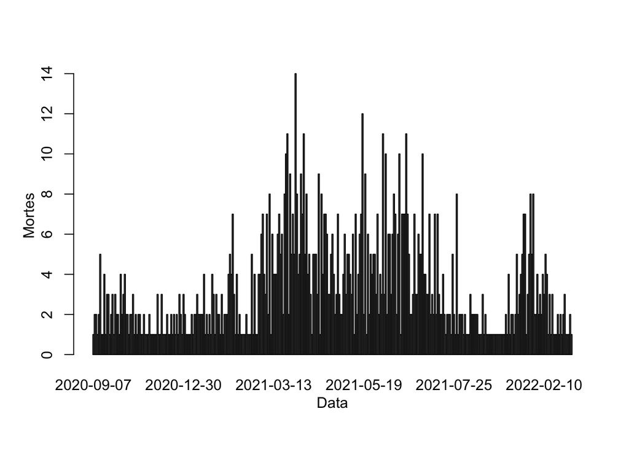

### Tipos de permanência hospitalar

Neste gráfico podemos observar os tipos de mortes por permanência hospitalar

```
## [1] 736
```

```
## [1] 378
```

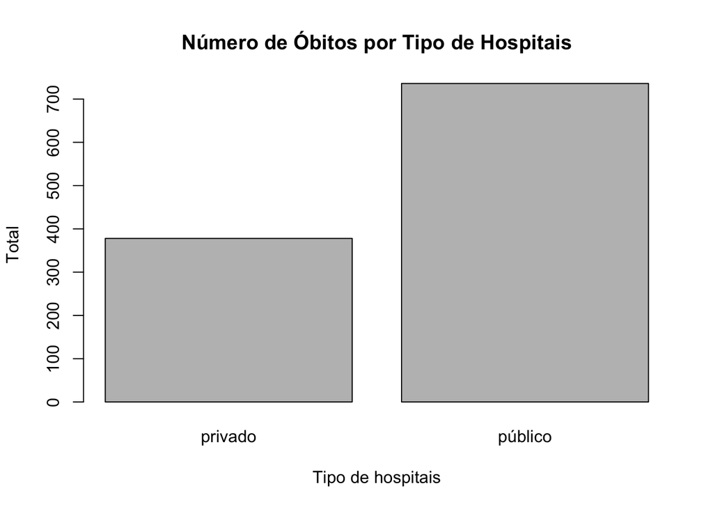

### Tempo de permanência hospitalar

Nestes dados, podemos observar o tempo de permanência hospitalar

[output not shown]

[output cut: 50 more lines]

### Relação entre óbitos e vacinados

Este gráfico observa a relação entre óbitos e vacinados

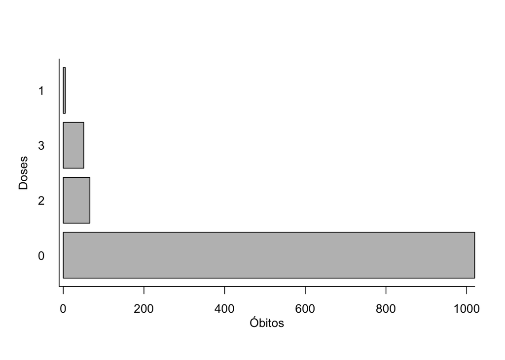